# Project_Report_Final

## Data Description

```python
econ_var_Nat_com_1.describe()#merged dataset without the economic variable 'Housing Units Sold'
```

|  | year | Federal_Funds | Recession_probability | revt | ni | month | norm | log_revt | y_1990 | y_1991 | ... | y_2014 | y_2015 | y_2016 | y_2017 | y_2018 | y_2019 | y_2020 | y_2021 | y_2022 | y_2023 |
| --- | --- | --- | --- | --- | --- | --- | --- | --- | --- | --- | --- | --- | --- | --- | --- | --- | --- | --- | --- | --- | --- |
| count | 10226.000000 | 10226.000000 | 10226.000000 | 10214.000000 | 10220.000000 | 10226.000000 | 10214.000000 | 10210.000000 | 10226.000000 | 10226.000000 | ... | 10226.000000 | 10226.000000 | 10226.000000 | 10226.000000 | 10226.000000 | 10226.000000 | 10226.000000 | 10226.000000 | 10226.000000 | 10226.000000 |
| mean | 2012.512028 | 1.371188 | 7.355629 | 3542.206730 | 461.354055 | 11.768140 | 1771.603365 | 4.480338 | 0.000196 | 0.000196 | ... | 0.052513 | 0.053393 | 0.052513 | 0.051731 | 0.050949 | 0.049971 | 0.049677 | 0.047428 | 0.045472 | 0.001956 |
| std | 5.771281 | 1.581461 | 19.460031 | 13428.530878 | 2118.472387 | 1.194169 | 6714.265439 | 2.126035 | 0.013984 | 0.013984 | ... | 0.223070 | 0.224828 | 0.223070 | 0.221494 | 0.219903 | 0.217895 | 0.217288 | 0.212563 | 0.208348 | 0.044183 |
| min | 1990.000000 | 0.078685 | 0.008333 | -6749.631000 | -34414.588000 | 3.000000 | -3374.315500 | -0.693147 | 0.000000 | 0.000000 | ... | 0.000000 | 0.000000 | 0.000000 | 0.000000 | 0.000000 | 0.000000 | 0.000000 | 0.000000 | 0.000000 | 0.000000 |
| 25% | 2008.000000 | 0.133726 | 0.091667 | 39.185000 | 4.431750 | 12.000000 | 20.092500 | 3.002000 | 0.000000 | 0.000000 | ... | 0.000000 | 0.000000 | 0.000000 | 0.000000 | 0.000000 | 0.000000 | 0.000000 | 0.000000 | 0.000000 | 0.000000 |
| 50% | 2013.000000 | 0.393197 | 0.166667 | 93.280500 | 13.722500 | 12.000000 | 47.140250 | 3.855082 | 0.000000 | 0.000000 | ... | 0.000000 | 0.000000 | 0.000000 | 0.000000 | 0.000000 | 0.000000 | 0.000000 | 0.000000 | 0.000000 | 0.000000 |
| 75% | 2017.000000 | 1.924180 | 0.958333 | 436.182250 | 75.099250 | 12.000000 | 218.591125 | 5.387713 | 0.000000 | 0.000000 | ... | 0.000000 | 0.000000 | 0.000000 | 0.000000 | 0.000000 | 0.000000 | 0.000000 | 0.000000 | 0.000000 | 0.000000 |
| max | 2023.000000 | 8.096521 | 80.221667 | 154792.000000 | 48334.000000 | 12.000000 | 77396.500000 | 11.256697 | 1.000000 | 1.000000 | ... | 1.000000 | 1.000000 | 1.000000 | 1.000000 | 1.000000 | 1.000000 | 1.000000 | 1.000000 | 1.000000 | 1.000000 |

8 rows × 42 columns

```python
econ_var_Nat_com_merged.describe()#merged dataset with the economic variable 'Housing Units Sold'
```

|  | year | Federal_Funds | Recession_probability | revt | ni | month | Housing_Units_Sold | norm | log_revt | y_2022 | y_2023 |
| --- | --- | --- | --- | --- | --- | --- | --- | --- | --- | --- | --- |
| count | 485.000000 | 485.000000 | 485.000000 | 485.000000 | 485.000000 | 485.000000 | 4.850000e+02 | 485.000000 | 485.000000 | 485.000000 | 485.000000 |
| mean | 2022.041237 | 1.828540 | 0.415732 | 5207.350542 | 928.841460 | 11.492784 | 4.195072e+06 | 2604.175271 | 5.124772 | 0.958763 | 0.041237 |
| std | 0.199043 | 0.658124 | 0.004512 | 16348.427716 | 3068.268581 | 1.732781 | 7.696347e+03 | 8174.213858 | 2.180143 | 0.199043 | 0.199043 |
| min | 2022.000000 | 1.692192 | 0.394000 | 6.325000 | -740.526000 | 3.000000 | 4.158000e+06 | 3.662500 | 1.298146 | 0.000000 | 0.000000 |
| 25% | 2022.000000 | 1.692192 | 0.416667 | 63.129000 | 15.080000 | 12.000000 | 4.196667e+06 | 32.064500 | 3.467749 | 1.000000 | 0.000000 |
| 50% | 2022.000000 | 1.692192 | 0.416667 | 181.900000 | 46.662000 | 12.000000 | 4.196667e+06 | 91.450000 | 4.515792 | 1.000000 | 0.000000 |
| 75% | 2022.000000 | 1.692192 | 0.416667 | 910.126000 | 250.178000 | 12.000000 | 4.196667e+06 | 455.563000 | 6.121534 | 1.000000 | 0.000000 |
| max | 2023.000000 | 4.998627 | 0.416667 | 154792.000000 | 37676.000000 | 12.000000 | 4.196667e+06 | 77396.500000 | 11.256697 | 1.000000 | 1.000000 |

```python
JP_df.describe()# description of only data from JP Morgan & Chase
```

|  | year | Federal_Funds | Recession_probability | revt | ni | month | norm | log_revt | y_1990 | y_1991 | ... | y_2014 | y_2015 | y_2016 | y_2017 | y_2018 | y_2019 | y_2020 | y_2021 | y_2022 | y_2023 |
| --- | --- | --- | --- | --- | --- | --- | --- | --- | --- | --- | --- | --- | --- | --- | --- | --- | --- | --- | --- | --- | --- |
| count | 20.00000 | 20.000000 | 20.000000 | 20.000000 | 20.000000 | 20.0 | 20.000000 | 20.000000 | 20.0 | 20.0 | ... | 20.000000 | 20.000000 | 20.000000 | 20.000000 | 20.000000 | 20.000000 | 20.000000 | 20.000000 | 20.000000 | 20.0 |
| mean | 2012.50000 | 1.301938 | 7.450917 | 107991.300000 | 21089.350000 | 12.0 | 53996.150000 | 10.861887 | 0.0 | 0.0 | ... | 0.050000 | 0.050000 | 0.050000 | 0.050000 | 0.050000 | 0.050000 | 0.050000 | 0.050000 | 0.050000 | 0.0 |
| std | 5.91608 | 1.545545 | 20.236915 | 25794.293584 | 11602.381962 | 0.0 | 12897.146792 | 0.291125 | 0.0 | 0.0 | ... | 0.223607 | 0.223607 | 0.223607 | 0.223607 | 0.223607 | 0.223607 | 0.223607 | 0.223607 | 0.223607 | 0.0 |
| min | 2003.00000 | 0.078685 | 0.051667 | 44363.000000 | 4466.000000 | 12.0 | 22182.000000 | 10.007036 | 0.0 | 0.0 | ... | 0.000000 | 0.000000 | 0.000000 | 0.000000 | 0.000000 | 0.000000 | 0.000000 | 0.000000 | 0.000000 | 0.0 |
| 25% | 2007.75000 | 0.138862 | 0.099167 | 101241.250000 | 13765.000000 | 12.0 | 50621.125000 | 10.832115 | 0.0 | 0.0 | ... | 0.000000 | 0.000000 | 0.000000 | 0.000000 | 0.000000 | 0.000000 | 0.000000 | 0.000000 | 0.000000 | 0.0 |
| 50% | 2012.50000 | 0.698078 | 0.207500 | 108961.000000 | 20130.000000 | 12.0 | 54481.000000 | 10.905459 | 0.0 | 0.0 | ... | 0.000000 | 0.000000 | 0.000000 | 0.000000 | 0.000000 | 0.000000 | 0.000000 | 0.000000 | 0.000000 | 0.0 |
| 75% | 2017.25000 | 1.857244 | 0.819583 | 119065.250000 | 25832.500000 | 12.0 | 59533.125000 | 10.993532 | 0.0 | 0.0 | ... | 0.000000 | 0.000000 | 0.000000 | 0.000000 | 0.000000 | 0.000000 | 0.000000 | 0.000000 | 0.000000 | 0.0 |
| max | 2022.00000 | 5.017315 | 80.221667 | 154792.000000 | 48334.000000 | 12.0 | 77396.500000 | 11.256697 | 0.0 | 0.0 | ... | 1.000000 | 1.000000 | 1.000000 | 1.000000 | 1.000000 | 1.000000 | 1.000000 | 1.000000 | 1.000000 | 0.0 |

8 rows × 42 columns

```python
BA_df.describe()# description of only data from Bank of America
```

|  | year | Federal_Funds | Recession_probability | revt | ni | month | norm | log_revt | y_1990 | y_1991 | ... | y_2014 | y_2015 | y_2016 | y_2017 | y_2018 | y_2019 | y_2020 | y_2021 | y_2022 | y_2023 |
| --- | --- | --- | --- | --- | --- | --- | --- | --- | --- | --- | --- | --- | --- | --- | --- | --- | --- | --- | --- | --- | --- |
| count | 20.00000 | 20.000000 | 20.000000 | 20.000000 | 20.000000 | 20.0 | 20.000000 | 20.000000 | 20.0 | 20.0 | ... | 20.000000 | 20.000000 | 20.000000 | 20.000000 | 20.000000 | 20.000000 | 20.000000 | 20.000000 | 20.000000 | 20.0 |
| mean | 2012.50000 | 1.301938 | 7.450917 | 103666.950000 | 14624.000000 | 12.0 | 51833.975000 | 10.829182 | 0.0 | 0.0 | ... | 0.050000 | 0.050000 | 0.050000 | 0.050000 | 0.050000 | 0.050000 | 0.050000 | 0.050000 | 0.050000 | 0.0 |
| std | 5.91608 | 1.545545 | 20.236915 | 22797.348956 | 9642.630887 | 0.0 | 11398.674478 | 0.248111 | 0.0 | 0.0 | ... | 0.223607 | 0.223607 | 0.223607 | 0.223607 | 0.223607 | 0.223607 | 0.223607 | 0.223607 | 0.223607 | 0.0 |
| min | 2003.00000 | 0.078685 | 0.051667 | 49006.000000 | -2238.000000 | 12.0 | 24503.500000 | 10.106571 | 0.0 | 0.0 | ... | 0.000000 | 0.000000 | 0.000000 | 0.000000 | 0.000000 | 0.000000 | 0.000000 | 0.000000 | 0.000000 | 0.0 |
| 25% | 2007.75000 | 0.138862 | 0.099167 | 93730.250000 | 5915.250000 | 12.0 | 46865.625000 | 10.755040 | 0.0 | 0.0 | ... | 0.000000 | 0.000000 | 0.000000 | 0.000000 | 0.000000 | 0.000000 | 0.000000 | 0.000000 | 0.000000 | 0.0 |
| 50% | 2012.50000 | 0.698078 | 0.207500 | 101057.000000 | 15435.000000 | 12.0 | 50529.000000 | 10.830283 | 0.0 | 0.0 | ... | 0.000000 | 0.000000 | 0.000000 | 0.000000 | 0.000000 | 0.000000 | 0.000000 | 0.000000 | 0.000000 | 0.0 |
| 75% | 2017.25000 | 1.857244 | 0.819583 | 115212.000000 | 18957.250000 | 12.0 | 57606.500000 | 10.961388 | 0.0 | 0.0 | ... | 0.000000 | 0.000000 | 0.000000 | 0.000000 | 0.000000 | 0.000000 | 0.000000 | 0.000000 | 0.000000 | 0.0 |
| max | 2022.00000 | 5.017315 | 80.221667 | 150450.000000 | 31978.000000 | 12.0 | 75225.500000 | 11.228246 | 0.0 | 0.0 | ... | 1.000000 | 1.000000 | 1.000000 | 1.000000 | 1.000000 | 1.000000 | 1.000000 | 1.000000 | 1.000000 | 0.0 |

8 rows × 42 columns

```python
IC_df.describe()# description of only data from ICICI Bank
```

|  | year | Federal_Funds | Recession_probability | revt | ni | month | norm | log_revt | y_1990 | y_1991 | ... | y_2014 | y_2015 | y_2016 | y_2017 | y_2018 | y_2019 | y_2020 | y_2021 | y_2022 | y_2023 |
| --- | --- | --- | --- | --- | --- | --- | --- | --- | --- | --- | --- | --- | --- | --- | --- | --- | --- | --- | --- | --- | --- |
| count | 21.000000 | 21.000000 | 21.000000 | 21.000000 | 21.000000 | 21.0 | 21.000000 | 21.000000 | 21.0 | 21.0 | ... | 21.000000 | 21.000000 | 21.000000 | 21.000000 | 21.000000 | 21.000000 | 21.000000 | 21.000000 | 21.000000 | 21.000000 |
| mean | 2012.714286 | 1.841731 | 8.412968 | 10756.606810 | 1387.576048 | 3.0 | 5378.803405 | 8.456727 | 0.0 | 0.0 | ... | 0.047619 | 0.047619 | 0.047619 | 0.047619 | 0.047619 | 0.047619 | 0.047619 | 0.047619 | 0.047619 | 0.047619 |
| std | 6.709269 | 2.048121 | 20.100911 | 4366.334683 | 998.999792 | 0.0 | 2183.167341 | 0.618354 | 0.0 | 0.0 | ... | 0.218218 | 0.218218 | 0.218218 | 0.218218 | 0.218218 | 0.218218 | 0.218218 | 0.218218 | 0.218218 | 0.218218 |
| min | 2000.000000 | 0.078685 | 0.051667 | 1929.051000 | 141.515000 | 3.0 | 965.025500 | 6.872155 | 0.0 | 0.0 | ... | 0.000000 | 0.000000 | 0.000000 | 0.000000 | 0.000000 | 0.000000 | 0.000000 | 0.000000 | 0.000000 | 0.000000 |
| 25% | 2008.000000 | 0.140574 | 0.101667 | 9273.371000 | 640.518000 | 3.0 | 4637.185500 | 8.441863 | 0.0 | 0.0 | ... | 0.000000 | 0.000000 | 0.000000 | 0.000000 | 0.000000 | 0.000000 | 0.000000 | 0.000000 | 0.000000 | 0.000000 |
| 50% | 2013.000000 | 1.002959 | 0.394000 | 11403.026000 | 1270.425000 | 3.0 | 5702.013000 | 8.648575 | 0.0 | 0.0 | ... | 0.000000 | 0.000000 | 0.000000 | 0.000000 | 0.000000 | 0.000000 | 0.000000 | 0.000000 | 0.000000 | 0.000000 |
| 75% | 2018.000000 | 3.217068 | 1.120000 | 13298.688000 | 1761.484000 | 3.0 | 6649.844000 | 8.802349 | 0.0 | 0.0 | ... | 0.000000 | 0.000000 | 0.000000 | 0.000000 | 0.000000 | 0.000000 | 0.000000 | 0.000000 | 0.000000 | 0.000000 |
| max | 2023.000000 | 6.237432 | 80.221667 | 17719.993000 | 4144.591000 | 3.0 | 8860.496500 | 9.089358 | 0.0 | 0.0 | ... | 1.000000 | 1.000000 | 1.000000 | 1.000000 | 1.000000 | 1.000000 | 1.000000 | 1.000000 | 1.000000 | 1.000000 |

8 rows × 42 columns

## Correlation between the revenue with the economic variables.

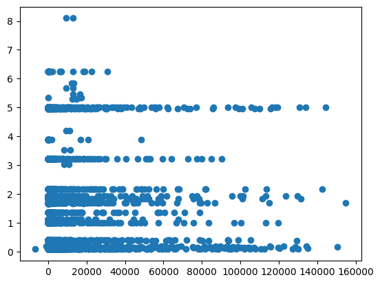

```python
plt.scatter(econ_var_Nat_com_1['revt'],econ_var_Nat_com_1['Federal_Funds'])

plt.show()
```

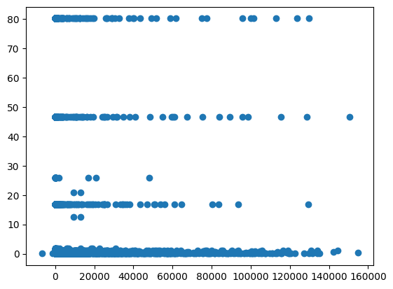

```python
plt.scatter(econ_var_Nat_com_1['revt'],econ_var_Nat_com_1['Recession_probability'])

plt.show()
```

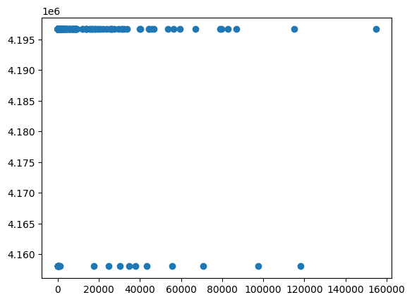

```python
plt.scatter(econ_var_Nat_com_merged['revt'],econ_var_Nat_com_merged['Housing_Units_Sold'])

plt.show()
```

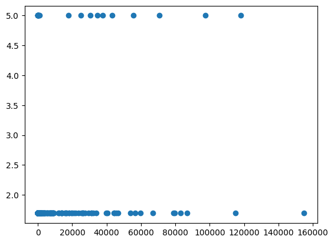

```python
plt.scatter(econ_var_Nat_com_merged['revt'],econ_var_Nat_com_merged['Federal_Funds'])

plt.show()
```

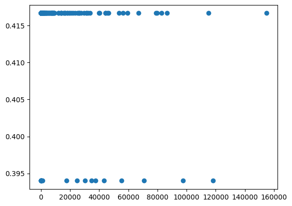

```python
plt.scatter(econ_var_Nat_com_merged['revt'],econ_var_Nat_com_merged['Recession_probability'])

plt.show()
```

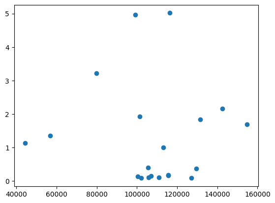

```python
plt.scatter(JP_df['revt'],JP_df['Federal_Funds'])

plt.show()
```

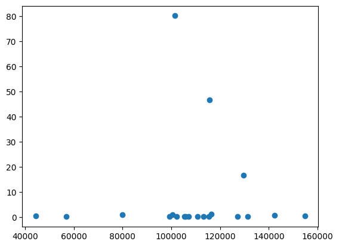

```python
plt.scatter(JP_df['revt'],JP_df['Recession_probability'])

plt.show()
```

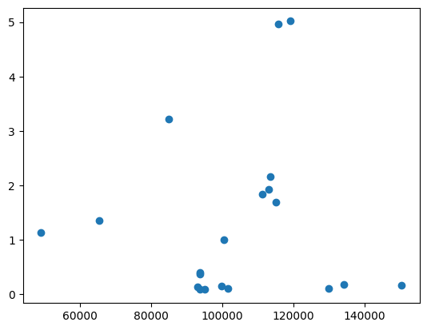

```python
plt.scatter(BA_df['revt'],BA_df['Federal_Funds'])

plt.show()
```

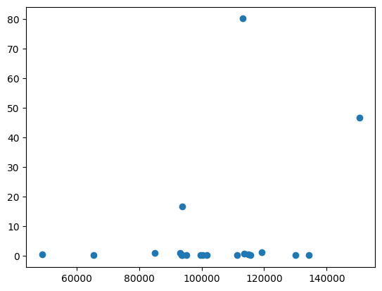

```python
plt.scatter(BA_df['revt'],BA_df['Recession_probability'])

plt.show()
```

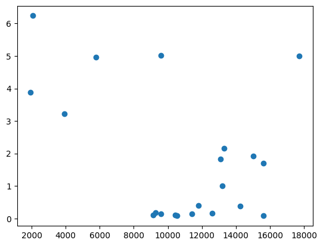

```python
plt.scatter(IC_df['revt'],IC_df['Federal_Funds'])

plt.show()
```

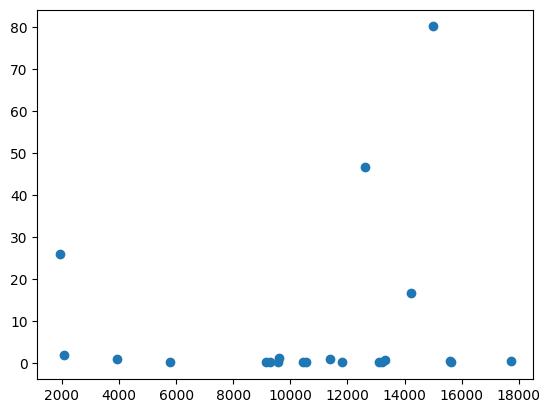

```python
plt.scatter(IC_df['revt'],IC_df['Recession_probability'])

plt.show()
```

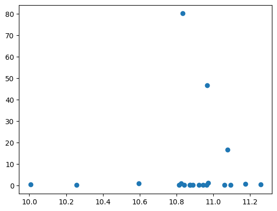

```python
plt.scatter(JP_df['log_revt'],JP_df['Recession_probability'])

plt.show()
```

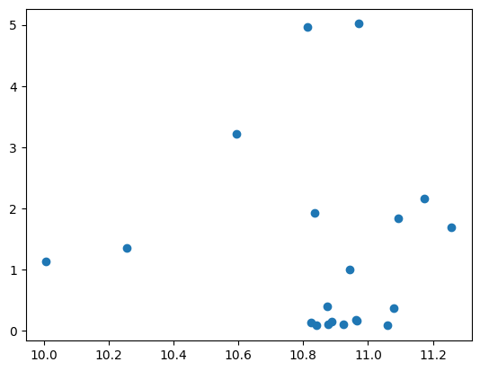

```python
plt.scatter(JP_df['log_revt'],JP_df['Federal_Funds'])

plt.show()
```

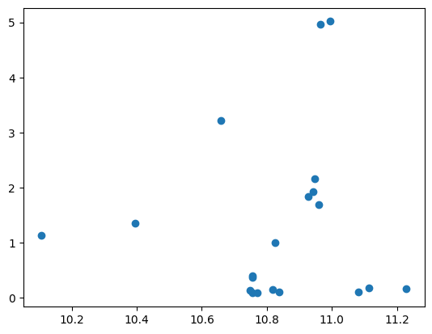

```python
plt.scatter(BA_df['log_revt'],BA_df['Federal_Funds'])

plt.show()
```

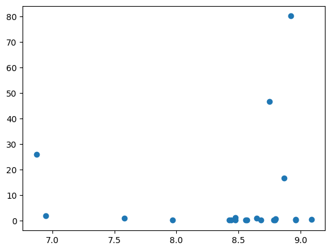

```python
plt.scatter(IC_df['log_revt'],IC_df['Recession_probability'])

plt.show()
```

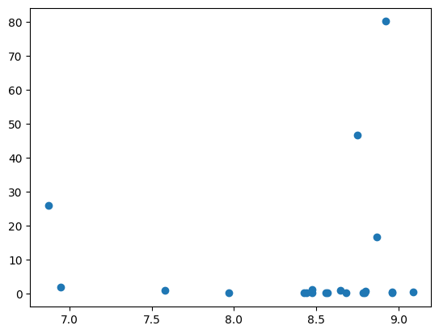

```python
plt.scatter(IC_df['log_revt'],IC_df['Recession_probability'])

plt.show()
```

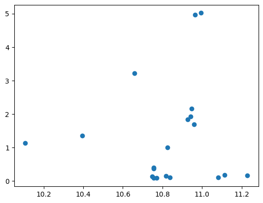

```python
plt.scatter(BA_df['log_revt'],BA_df['Federal_Funds'])

plt.show()
```

## Adjusting the datasets for missing value

```python
# checking the missing values
econ_var_Nat_com_1.isnull().sum()
```

```
year                       0
Federal_Funds              0
Recession_probability      0
cik                      401
gvkey                      0
datadate                   0
conm                       0
revt                      12
ni                         6
month                      0
norm                      12
log_revt                  16
y_1990                     0
y_1991                     0
y_1992                     0
y_1993                     0
y_1994                     0
y_1995                     0
y_1996                     0
y_1997                     0
y_1998                     0
y_1999                     0
y_2000                     0
y_2001                     0
y_2002                     0
y_2003                     0
y_2004                     0
y_2005                     0
y_2006                     0
y_2007                     0
y_2008                     0
y_2009                     0
y_2010                     0
y_2011                     0
y_2012                     0
y_2013                     0
y_2014                     0
y_2015                     0
y_2016                     0
y_2017                     0
y_2018                     0
y_2019                     0
y_2020                     0
y_2021                     0
y_2022                     0
y_2023                     0
dtype: int64
```

```python
econ_var_Nat_com_1 = econ_var_Nat_com_1.dropna(subset=['revt','ni'])
econ_var_Nat_com_1.isnull().sum()
```

```
year                       0
Federal_Funds              0
Recession_probability      0
cik                      399
gvkey                      0
datadate                   0
conm                       0
revt                       0
ni                         0
month                      0
norm                       0
log_revt                   4
y_1990                     0
y_1991                     0
y_1992                     0
y_1993                     0
y_1994                     0
y_1995                     0
y_1996                     0
y_1997                     0
y_1998                     0
y_1999                     0
y_2000                     0
y_2001                     0
y_2002                     0
y_2003                     0
y_2004                     0
y_2005                     0
y_2006                     0
y_2007                     0
y_2008                     0
y_2009                     0
y_2010                     0
y_2011                     0
y_2012                     0
y_2013                     0
y_2014                     0
y_2015                     0
y_2016                     0
y_2017                     0
y_2018                     0
y_2019                     0
y_2020                     0
y_2021                     0
y_2022                     0
y_2023                     0
dtype: int64
```

### We need to remove the rows with missing values in *revenue* and *net income since* because only 12 data are missing which does not affect the analysis at all, plus our analysis requires a complete dataset which is not possible with the missing values.

```python
econ_var_Nat_com_merged.isnull().sum()
```

```
year                      0
Federal_Funds             0
Recession_probability     0
cik                      22
gvkey                     0
datadate                  0
conm                      0
revt                      0
ni                        0
month                     0
Housing_Units_Sold        0
norm                      0
log_revt                  0
y_2022                    0
y_2023                    0
dtype: int64
```

### missing values in CIK will not affect the analysis since we have the primary key *'gvkey'+'year'*

```python
JP_df.isnull().sum()
```

```
year                     0
Federal_Funds            0
Recession_probability    0
cik                      0
gvkey                    0
datadate                 0
conm                     0
revt                     0
ni                       0
month                    0
norm                     0
log_revt                 0
y_1990                   0
y_1991                   0
y_1992                   0
y_1993                   0
y_1994                   0
y_1995                   0
y_1996                   0
y_1997                   0
y_1998                   0
y_1999                   0
y_2000                   0
y_2001                   0
y_2002                   0
y_2003                   0
y_2004                   0
y_2005                   0
y_2006                   0
y_2007                   0
y_2008                   0
y_2009                   0
y_2010                   0
y_2011                   0
y_2012                   0
y_2013                   0
y_2014                   0
y_2015                   0
y_2016                   0
y_2017                   0
y_2018                   0
y_2019                   0
y_2020                   0
y_2021                   0
y_2022                   0
y_2023                   0
dtype: int64
```

```python
BA_df.isnull().sum()
```

```
year                     0
Federal_Funds            0
Recession_probability    0
cik                      0
gvkey                    0
datadate                 0
conm                     0
revt                     0
ni                       0
month                    0
norm                     0
log_revt                 0
y_1990                   0
y_1991                   0
y_1992                   0
y_1993                   0
y_1994                   0
y_1995                   0
y_1996                   0
y_1997                   0
y_1998                   0
y_1999                   0
y_2000                   0
y_2001                   0
y_2002                   0
y_2003                   0
y_2004                   0
y_2005                   0
y_2006                   0
y_2007                   0
y_2008                   0
y_2009                   0
y_2010                   0
y_2011                   0
y_2012                   0
y_2013                   0
y_2014                   0
y_2015                   0
y_2016                   0
y_2017                   0
y_2018                   0
y_2019                   0
y_2020                   0
y_2021                   0
y_2022                   0
y_2023                   0
dtype: int64
```

```python
IC_df.isnull().sum()
```

```
year                     0
Federal_Funds            0
Recession_probability    0
cik                      0
gvkey                    0
datadate                 0
conm                     0
revt                     0
ni                       0
month                    0
norm                     0
log_revt                 0
y_1990                   0
y_1991                   0
y_1992                   0
y_1993                   0
y_1994                   0
y_1995                   0
y_1996                   0
y_1997                   0
y_1998                   0
y_1999                   0
y_2000                   0
y_2001                   0
y_2002                   0
y_2003                   0
y_2004                   0
y_2005                   0
y_2006                   0
y_2007                   0
y_2008                   0
y_2009                   0
y_2010                   0
y_2011                   0
y_2012                   0
y_2013                   0
y_2014                   0
y_2015                   0
y_2016                   0
y_2017                   0
y_2018                   0
y_2019                   0
y_2020                   0
y_2021                   0
y_2022                   0
y_2023                   0
dtype: int64
```